# 8. Life/Death Population (Extra Credit)

- Show All Code
- Hide All Code
- View Source

An irregular, bimodal, real-world-inspired distribution

Author

Richa Vakharia

```r
source("R/clt_helpers.R")
```

## 1 What population am I sampling from?

The custom age-at-death distribution from the class handout. Ages are whole numbers from 0 to 100, and the probabilities come from mixing two pieces:

- an **early-death** piece that starts high at age 0 and decays quickly: $0.045\,e^{-x/5}$
- an **adult-death** piece shaped like a bell curve centered at 65: $0.030\,e^{-\frac12\left(\frac{x-65}{10}\right)^2}$

Then everything is divided by the total so the probabilities add to 1. This is a synthetic distribution built to have a realistic shape. It’s not a real life table.

```r
age    <- 0:100
weight <- 0.045 * exp(-age / 5) + 0.030 * exp(-0.5 * ((age - 65) / 10)^2)
prob   <- weight / sum(weight)

death_distribution <- data.frame(age = age, probability = prob)
sum(death_distribution$probability)   # should be 1
```

```
[1] 1
```

```r
rdeath <- function(n) {
  sample(death_distribution$age, size = n, replace = TRUE,
         prob = death_distribution$probability)
}
```

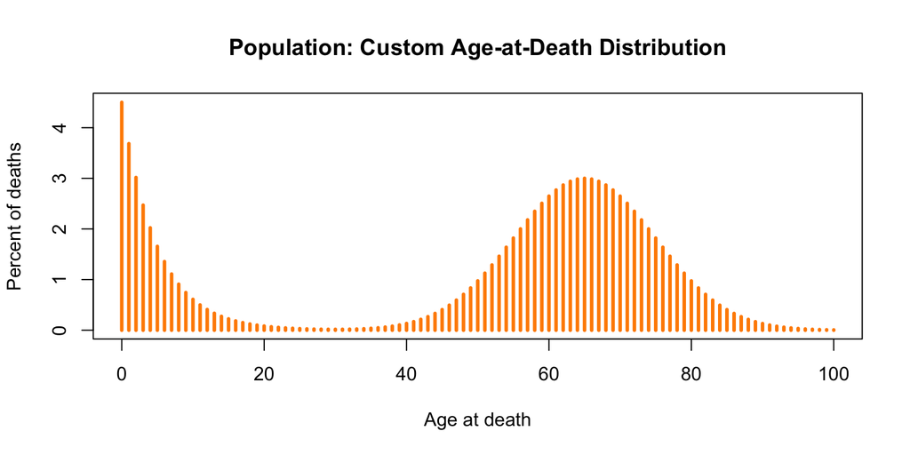

```r
plot(age, 100 * prob, type = "h", lwd = 3, col = "darkorange",
     xlab = "Age at death", ylab = "Percent of deaths",
     main = "Population: Custom Age-at-Death Distribution")
```

```r
mu    <- sum(age * prob)
sigma <- sqrt(sum((age - mu)^2 * prob))
g1    <- sum(((age - mu) / sigma)^3 * prob)
g2    <- sum(((age - mu) / sigma)^4 * prob) - 3
data.frame(mean = mu, sd = sigma, skewness = g1, excess_kurtosis = g2,
           median = age[which(cumsum(prob) >= 0.5)[1]])
```

```
      mean       sd   skewness excess_kurtosis median
1 49.98098 27.63452 -0.8621713      -0.7900849     61
```

This population is **bimodal** (two peaks), **left-skewed** (skewness -0.86, because the early-death bump pulls a tail toward 0), and has **negative excess kurtosis** (-0.79), because the probability is spread out across two humps instead of piled up in the middle. The mean (50) lands in the gap between the two peaks, at an age where very few people actually die. So the “average age at death” doesn’t describe a typical person at all.

## 2 What did I expect?

Bimodal sounds scary, but the CLT only cares about finite variance, and this population is bounded between 0 and 100, so the variance is definitely finite. Based on skewness:

```r
predicted_n(g1, g2)
```

```
  from_skewness from_kurtosis prediction
1            12             2         12
```

I expect it to converge somewhere around $n = 12$: faster than the exponential (skewness 2) but slower than the die (skewness 0). I’m also expecting the two humps to disappear quickly, since averaging even 2 or 3 people mixes “early” and “adult” deaths together.

## 3 Which sample sizes did I investigate?

The standard grid from 1 to 500, with $B = 10,000$ repetitions at each $n$.